# Supervised Learning Case: Predicting potential customers for a personal loan in a financial institution

By Leonardo Castro

# **Introduction: Classification Models**

In fin-tech companies data is one of the main assets, however, the **value of the data** can be evaluated when the organization can extract the valuable knowledge hidden in the raw data.

Machine Learning classification models are extremely useful to predict customer’s behavior in many different scenarios. **Classification algorithms** are a type of supervised learning models where they learn from labeled data. After understanding the data, the algorithm determines which label should be given to new data by associating patterns to the unlabeled new data.

Some of the most used classification algorithms are *Logistic Regression*, *Decision Tree*, *Random Forest*, *Support Vector Machines*, *K-Nearest Neighbour* and *Naive Bayes*, to mention a few. We will take a closer look to some of them later on.

Below you can see a simple illustration of those algorithms taken from [**this useful article.**](https://towardsdatascience.com/top-machine-learning-algorithms-for-classification-2197870ff501)

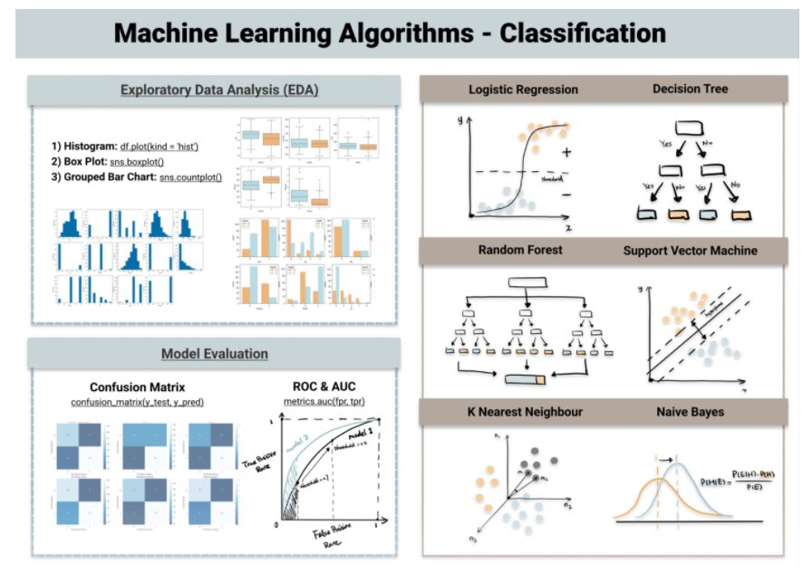

In this context, I will train some Machine Learning algorithms commonly used for classification and try to explain how they perform for then compare them with each other when applied to customer data from a financial institution.

Before diving deep into code and statistics, let’s understand the business case and what would be the benefits of applying this classification models.

# **Business Understanding**

## Case Statement

Loans represents the main income from banks, which comes from the loan’s interests. By this premise, banks definitely will be looking for prospective customers in order to encourage and persuade them to take a personal loan and consequently increase their income by the profitable interests.

Marketing efforts should be directed to those prospective customers likely to take the loan and that is the reason the analytics team from a financial institution would like to model and predict which new/passive customers are prospectives to become personal loan customers.

There is data from around 5000 customers from a past marketing campaign which had recent success. It was targeted to convert trusted passive customers to personal loan customers. This valuable asset (**raw data**) can be converted into a powerful tool to increase conversion rate success on the company.

Let’s find out how Data Science extracts the gold from the raw data.

## Objective

The **objective** of this analysis is to model the characteristics of the clients of the previous campaign in order to analyze what combination of factors make a client more likely to accept a personal loan. By modeling this factors we will construct a model able to predict if new customers are prospective/have higher probability to get a personal loan.

## Business Benefit

To help Business Development and Marketing Teams to create product & marketing strategies targeted to those prospective customers more likely to become personal loan customers and ensure its efforts and resources are going to be spent on the right people. Consequently, we expect more revenue coming from loan’s interests making more profitable the business.

## Scope

This analysis parts from the hypothesis that all the customers being analyzed are trusted customers, for hence, eligible customers to get a loan. I am not analyzing whether the customers are good or bad payers.

Also I want to clarify all the insights come strictly from the data and not from subjective opinion. However, we should have opinion from a Subject Matter Expert (SME) to get better understanding of some policies or rules on loan and fin-tech business.

## Key Business Questions

- How are characterized the personal loan customers?
- What is the most important variable/s which defines if a customer will get a loan customer?
- What is the expected accuracy of the model to be developed? Will it predict correctly?

## Expected Outcomes

- To obtain an accurate model which can predict prospective customers likely to get a personal loan.
- To know which variables or characteristics are the most important to know in order to convert a new customer into a personal loan customer.

# **Methodology & Analytics Techniques Used**

- Data understanding
- Data cleaning and preparation.
- Exploratory data analysis.
- Data splitting (training/test).
- Machine Learning Classification Models:
  - Logistic Regression.
  - Classification Trees.
  - Random Forest.
  - K-Nearest Neighbors.

```r
#These are the R packages used for the analysis.
library(knitr)
library(dplyr)
library(tidyr)
library(ggplot2)
library(hrbrthemes)
library(yardstick)
library(rpart)
library(rpart.plot)
library(caret)
library(randomForest)
library(class)
library(ROCit)
```

## Data Understanding

- Data consists in customers’ personal information from a financial institution.
- Data was directly downloaded from a GitHub repository. You can find it [**here.**](https://github.com/gchoi/Dataset/blob/master/UniversalBank.csv)
- The dat aset has 14 columns and 5000 rows.
- Data dictionary:
  - **ID:** customer id.
  - **Age:** customer’s age in completed years.
  - **Experience:** number of years of professional experience.
  - **Income:** annual customer earnings ($ thousands).
  - **ZIP.Code:** customer’s address zip code.
  - **Family:** family size.
  - **CCAvg:** average credit card spend per month ($ thousands).
  - **Education:** Level of studies, 1= Undergraduate, 2= Graduate, 3= Advanced/Professional.
  - **Mortgage:** mortgage value of the house.
  - **Personal.Loan:** coded with 1 if the client has accepted the personal loan from the bank in the previous campaign. This variable is going to be the **predictor/dependent variable.**
  - **Securities.Account:** coded with 1 if the client has a security account with the bank.
  - **CD.Account:** coded with 1 if the client has a certificate of deposit (CD) with the bank.
  - **Online:** coded 1 if the client has online services with the bank.
  - **CreditCard:** coded 1 if the customer uses has at least one credit card with the bank.

```r
#Read database
bank <- read.csv("UniversalBank.csv")

#Head 5 first rows from database
kable(head(bank,5),  caption="**Table 1.** First five rows from bank database.")
```

**Table 1.** First five rows from bank database.

| ID | Age | Experience | Income | ZIP.Code | Family | CCAvg | Education | Mortgage | Personal.Loan | Securities.Account | CD.Account | Online | CreditCard |
| --- | --- | --- | --- | --- | --- | --- | --- | --- | --- | --- | --- | --- | --- |
| 1 | 25 | 1 | 49 | 91107 | 4 | 1.6 | 1 | 0 | 0 | 1 | 0 | 0 | 0 |
| 2 | 45 | 19 | 34 | 90089 | 3 | 1.5 | 1 | 0 | 0 | 1 | 0 | 0 | 0 |
| 3 | 39 | 15 | 11 | 94720 | 1 | 1.0 | 1 | 0 | 0 | 0 | 0 | 0 | 0 |
| 4 | 35 | 9 | 100 | 94112 | 1 | 2.7 | 2 | 0 | 0 | 0 | 0 | 0 | 0 |
| 5 | 35 | 8 | 45 | 91330 | 4 | 1.0 | 2 | 0 | 0 | 0 | 0 | 0 | 1 |

## Data Cleaning and Preparation.

Findings and actions:

- There are not missing values on the database.
- I found an error on variable *Experience*, which corresponds to value -3. This value is incorrect as the minimum value for the variable Experience has to be 0 as there are not negative years of experience. Probably is a data entry error, so I proceeded replacing for a 0.
- There are two variables not suitable for the analysis: *ID* and *ZIP.Code*. I proceed eliminating them.
- Categorical variables have been read as numerical, so I proceed converting them to factor, as we need it for the further steps.

```r
#Function to get percentage of missing values
NAporcent <- function(x, ndec=2){
  porcent=(sum(is.na(x))/length(x))*100
  p2 = round(porcent, digits=ndec)
}

#Look if there are missing values
sum(apply(bank, 2, NAporcent))
```

```
## [1] 0
```

```r
# Check data types and range for each variable
descriptive <- cbind(t(apply(bank, 2, range, na.rm = TRUE)), apply(bank, 2, class))
colnames(descriptive) <- c("Min","Max", "Data Type")
kable(descriptive, caption="**Table 2.** Variables range and data type", digits=2)
```

**Table 2.** Variables range and data type

|  | Min | Max | Data Type |
| --- | --- | --- | --- |
| ID | 1 | 5000 | numeric |
| Age | 23 | 67 | numeric |
| Experience | -3 | 43 | numeric |
| Income | 8 | 224 | numeric |
| ZIP.Code | 9307 | 96651 | numeric |
| Family | 1 | 4 | numeric |
| CCAvg | 0 | 10 | numeric |
| Education | 1 | 3 | numeric |
| Mortgage | 0 | 635 | numeric |
| Personal.Loan | 0 | 1 | numeric |
| Securities.Account | 0 | 1 | numeric |
| CD.Account | 0 | 1 | numeric |
| Online | 0 | 1 | numeric |
| CreditCard | 0 | 1 | numeric |

```r
# Delete ID y ZIP.CODE columns
bank2 <- bank[ , -c(1, 5)]

# Correct data error
bank2$Experience[bank$Experience<0]<-0

# Create categorical and binary variables (convert as factor)
bank2$Education <- factor(bank$Education, c(1, 2, 3), c("Undergraduate", "Graduate", "Advanced/Professional"))
bank2$Securities.Account<-factor(bank$Securities.Account)
bank2$CD.Account<- factor(bank$CD.Account)
bank2$Online<- factor(bank$Online)
bank2$CreditCard<-factor(bank$CreditCard)
bank2$Personal.Loan<-factor(bank$Personal.Loan)
```

## Exploratory Data Analysis

- **Do the customers who accepted the personal loan have more services in the same bank as Security Account, Certificate of Deposit, Online Services, Credit Card?**

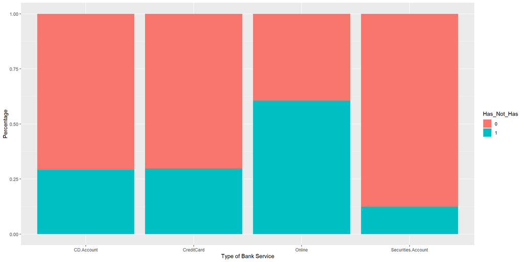

**Figure 1.** Percentage of loan customers who has another bank services: Security Account, Certificate of Deposit, Online Services or Credit Cards.

```r
#Preparing data to plot
q1 <- bank2 %>% filter(Personal.Loan == 1) %>%
  select(Securities.Account, CD.Account, Online, CreditCard) %>%
  pivot_longer(c(Securities.Account, CD.Account, Online, CreditCard), names_to = "Type_of_Service", values_to = "Yes_No") %>%
  group_by(Type_of_Service) %>%
  mutate(Percentage=sum(as.numeric(Yes_No)))
colnames(q1)[2] <- "Has_Not_Has"
#Plotting barplot
ggplot(q1, aes(x = Type_of_Service, y=Percentage, fill=Has_Not_Has)) + geom_col(position = "fill")+xlab("Type of Bank Service")
```

- **How are the salaries distributed? Is there any difference regarding the education? Are differences on the customers who accepted/rejected the loan?**

It seems customers with higher salaries tend to get the loan, independently of the education level. Figure also shows there’s a gap of salary on undergraduate customers, where there is people which earns more than /$200k per year and in the other hand, people who earn around $10k per year. This quick insight let us have the hypothesis that income will be one of the most important variables to define the model.

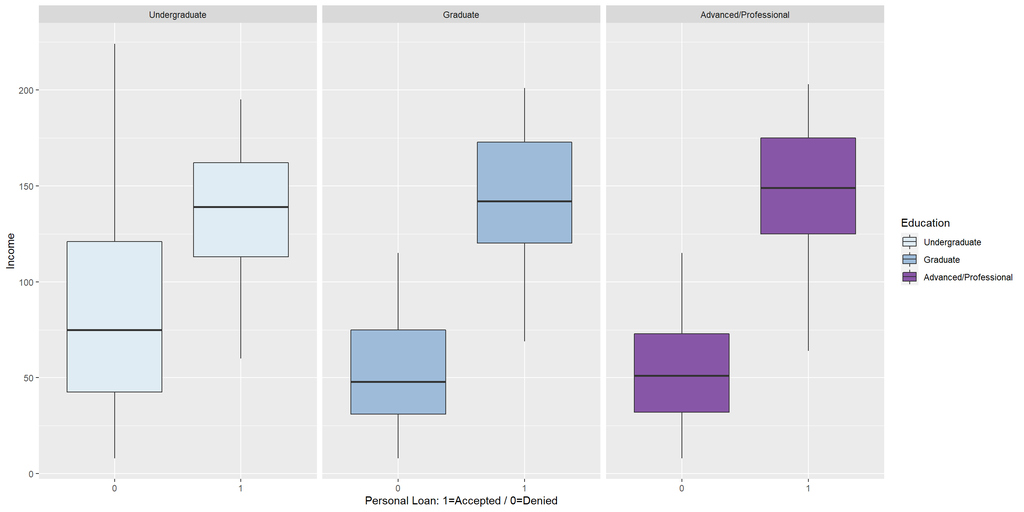

**Figure 2.** Salaries distribution in customer who accepted and not accepted the loan according with education level.

```r
#Boxplot
  ggplot(bank2, aes(x=Personal.Loan, y=Income, fill=Education))+geom_boxplot()+facet_grid(~Education) +  scale_fill_brewer(palette="BuPu")+xlab("Personal Loan: 1=Accepted / 0=Denied")
```

- **What is the size of families? How are the frequencies per family group size?**

It seems like there is a slight difference between the family size groups on those customers who accepted the loan. It may not be an important variable to consider on the models, however, is just a hypothesis we will definitely confirm on further steps.

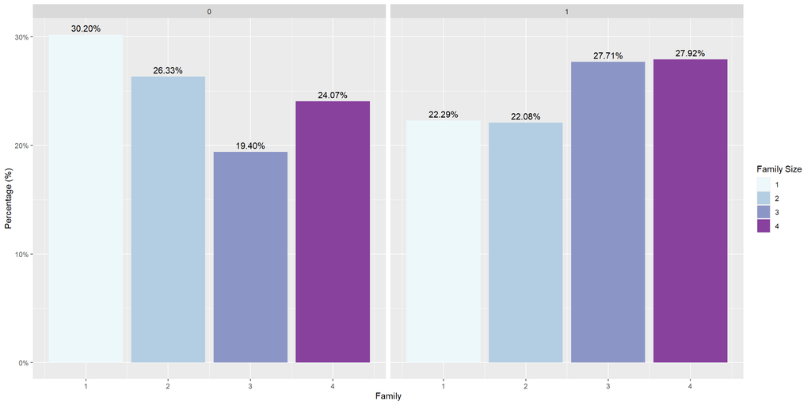

**Figure 3.** Frecuency of family group sizes in loan/not loan customers.

```r
#Barplot showing percentage of family size
ggplot(bank2, aes(x= Family,  group=Personal.Loan)) +
    geom_bar(aes(y = ..prop.., fill = factor(..x..)), stat="count") +
    geom_text(aes( label = scales::percent(..prop..),
                   y= ..prop.. ), stat= "count", vjust = -.5) +
    labs(y = "Percentage (%)", fill="Family Size") +
    facet_grid(~Personal.Loan) +
    scale_y_continuous(labels = scales::percent) +
  scale_fill_brewer(palette="BuPu")
```

- **What is the average credit card spent per month on personal loan customers?**

As we can see on the density plot, most of the loan customers spent around $ 2500 and $ 5000 dollars in credit card. This can be a really useful information at the time of setting the loan amounts to offer to the clients.

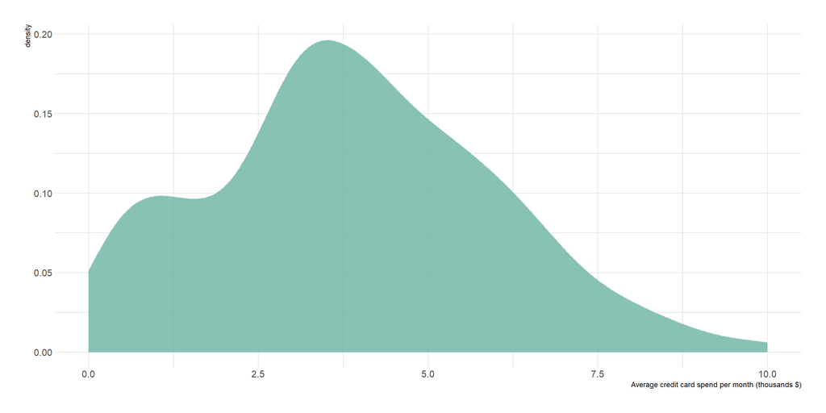

**Figure 4.** Distribution of average credit card spend per month on personal loan customers.

```r
bank2 %>% filter(Personal.Loan==1) %>%
  ggplot(aes(x=CCAvg)) +
    geom_density(fill="#69b3a2", color="#e9ecef", alpha=0.8) +
    theme_ipsum()+xlab("Average credit card spend per month (thousands $)")
```

## Data splitting (Train and Test)

In order to evaluate the accuracy of the classification models, the data must be partitioned into training and test data sets. The training partition is used to build the model, and the test partition is used to see how well the model performs when applied to new data and measure its error. For the partition, we will take 70% of the data for training and 30% for testing.

```r
set.seed(777)
#Test/training partitions are created using createDataPartition
trainIndex <- createDataPartition(bank2$Personal.Loan, p = 0.7,  list = FALSE, times = 1)
#CreateDataPartition function from library caret ensures stratified sampling, so that the 1 and 0 are represented in train and test in the same proportion as in the original sample.
#Creating training/test data sets
banktrain <- bank2[trainIndex,]
banktest  <- bank2[-trainIndex,]
```

## Classification Models

Let’s recap: the **main goal** of the analysis is to predict whether or not a new customer will accept a personal loan using the predictor variable *Personal.Loan*. This is what I will be training with the supervised classification algorithms in the next steps.

### Logistic Regression

Logistic regression works very similar to linear regression, but with a binomial response variable. Instead of fitting a straight line or hyperplane, the logistic regression model uses the logistic function to squeeze the output of a linear equation between 0 and 1.

The interpretation of the weights in logistic regression differs from the interpretation of the weights in linear regression, the weights do not influence the probability linearly any longer. The weighted sum is transformed by the logistic function to a probability. Therefore we need to reformulate the equation for the interpretation so that only the linear term is on the right side of the formula.

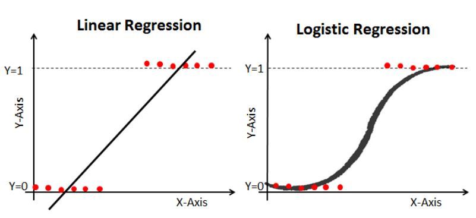

[**Image taken from this valuable article.**](https://www.analyticsvidhya.com/blog/2021/08/conceptual-understanding-of-logistic-regression-for-data-science-beginners/)

We call the term in the ln() function “odds” (probability of event divided by probability of no event) and wrapped in the logarithm it is called log odds.

$$\begin{aligned}\log\left( \frac { p }{ 1 - p} \right) &= \beta_{0} + \beta_{1}X_1 + \beta_{2}X_2 + \beta_{3}X_3 + ... + \beta_{n}X_n
\end{aligned}$$

Let’s train the data with a logistic regression model.

```r
#Training the model
logit <- glm(Personal.Loan ~ ., data = banktrain, family = "binomial")
options(scipen=999) #avoid scientific notation
summary(logit)
```

```
##
## Call:
## glm(formula = Personal.Loan ~ ., family = "binomial", data = banktrain)
##
## Deviance Residuals:
##     Min       1Q   Median       3Q      Max
## -2.2430  -0.1827  -0.0679  -0.0206   4.2077
##
## Coefficients:
##                                   Estimate  Std. Error z value
## (Intercept)                    -11.9952847   2.0846085  -5.754
## Age                             -0.0538431   0.0772942  -0.697
## Experience                       0.0607727   0.0768254   0.791
## Income                           0.0613880   0.0035332  17.375
## Family                           0.6275270   0.0943622   6.650
## CCAvg                            0.1522357   0.0518044   2.939
## EducationGraduate                4.0261895   0.3239880  12.427
## EducationAdvanced/Professional   4.1825989   0.3202037  13.062
## Mortgage                         0.0008852   0.0007133   1.241
## Securities.Account1             -0.8794079   0.3655611  -2.406
## CD.Account1                      3.9074788   0.4146202   9.424
## Online1                         -0.7879970   0.1975200  -3.989
## CreditCard1                     -1.0270698   0.2490546  -4.124
##                                            Pr(>|z|)
## (Intercept)                         0.0000000087045 ***
## Age                                          0.4861
## Experience                                   0.4289
## Income                         < 0.0000000000000002 ***
## Family                              0.0000000000293 ***
## CCAvg                                        0.0033 **
## EducationGraduate              < 0.0000000000000002 ***
## EducationAdvanced/Professional < 0.0000000000000002 ***
## Mortgage                                     0.2146
## Securities.Account1                          0.0161 *
## CD.Account1                    < 0.0000000000000002 ***
## Online1                             0.0000662256860 ***
## CreditCard1                         0.0000372552333 ***
## ---
## Signif. codes:  0 '***' 0.001 '**' 0.01 '*' 0.05 '.' 0.1 ' ' 1
##
## (Dispersion parameter for binomial family taken to be 1)
##
##     Null deviance: 2213.43  on 3499  degrees of freedom
## Residual deviance:  820.49  on 3487  degrees of freedom
## AIC: 846.49
##
## Number of Fisher Scoring iterations: 8
```

```r
logit2 <- glm(Personal.Loan ~ Income*Family+Income*CCAvg+., data = banktrain[ , -which(names(banktrain) %in% c("Age","Experience", "Mortgage", "Securities.Account"))], family = "binomial")
summary(logit2)
```

```
##
## Call:
## glm(formula = Personal.Loan ~ Income * Family + Income * CCAvg +
##     ., family = "binomial", data = banktrain[, -which(names(banktrain) %in%
##     c("Age", "Experience", "Mortgage", "Securities.Account"))])
##
## Deviance Residuals:
##     Min       1Q   Median       3Q      Max
## -2.1924  -0.1127  -0.0212  -0.0026   3.9632
##
## Coefficients:
##                                  Estimate Std. Error z value
## (Intercept)                    -13.141713   1.255654 -10.466
## Income                           0.045788   0.009043   5.064
## Family                          -2.642112   0.420604  -6.282
## CCAvg                            2.212994   0.245280   9.022
## EducationGraduate                4.782551   0.373636  12.800
## EducationAdvanced/Professional   4.669327   0.349968  13.342
## CD.Account1                      3.443309   0.436870   7.882
## Online1                         -0.680159   0.225539  -3.016
## CreditCard1                     -1.153038   0.285145  -4.044
## Income:Family                    0.030546   0.003804   8.029
## Income:CCAvg                    -0.013772   0.001603  -8.593
##                                            Pr(>|z|)
## (Intercept)                    < 0.0000000000000002 ***
## Income                         0.000000411623260976 ***
## Family                         0.000000000334864982 ***
## CCAvg                          < 0.0000000000000002 ***
## EducationGraduate              < 0.0000000000000002 ***
## EducationAdvanced/Professional < 0.0000000000000002 ***
## CD.Account1                    0.000000000000003228 ***
## Online1                                     0.00256 **
## CreditCard1                    0.000052615706723377 ***
## Income:Family                  0.000000000000000981 ***
## Income:CCAvg                   < 0.0000000000000002 ***
## ---
## Signif. codes:  0 '***' 0.001 '**' 0.01 '*' 0.05 '.' 0.1 ' ' 1
##
## (Dispersion parameter for binomial family taken to be 1)
##
##     Null deviance: 2213.43  on 3499  degrees of freedom
## Residual deviance:  614.57  on 3489  degrees of freedom
## AIC: 636.57
##
## Number of Fisher Scoring iterations: 9
```

I checked all the variables are significant (**p-value < 0.05**). Now let’s proceed to use the trained model to predict on the test data.

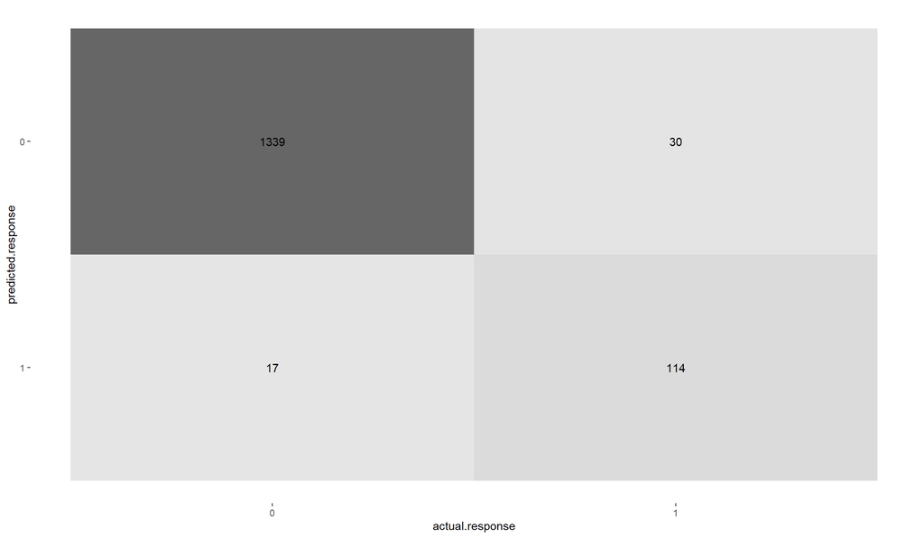

**Figure 5.** Confusion matrix for Logistic Regression Model.

```r
#Prediction
pred.logit.test<-predict(logit2, banktest, type = "response")

#Create confusion matrix
predicted.response <- round(pred.logit.test)
actual.response <- banktest$Personal.Loan
outcomeslm <- table(predicted.response, actual.response)
confusionlm <- conf_mat(outcomeslm)

#Plot confusion matrix
autoplot(confusionlm, type="heatmap")
```

```r
#Performance metrics
performancelm <- summary(confusionlm, event_level="second") %>% select(.metric, .estimate)
```